# Homework 3

Kevin Russell

# Problem 1 [25 Points Total]

I have shared the_office_data.csv on HuskyCT. It is a dataset consisting of one row for each episode of the office.

## Part A [5 points]

Read the dataset into R.

```r
library(dplyr)
library(tidyverse)
```

```r
library(ggplot2)
library(jpeg)
library(raster)
library(rvest)
office <- read.csv("C:/Users/kruss/Downloads/the_office_data.csv")

office |>
  glimpse()
```

```
## Rows: 186
## Columns: 5
## $ season       <int> 1, 1, 1, 1, 1, 1, 2, 2, 2, 2, 2, 2, 2, 2, 2, 2, 2, 2, 2, …
## $ episode      <int> 1, 2, 3, 4, 5, 6, 1, 2, 3, 4, 5, 6, 7, 8, 9, 10, 11, 12, …
## $ episode_name <chr> "Pilot", "Diversity Day", "Health Care", "The Alliance", …
## $ writer       <chr> "Ricky Gervais;Stephen Merchant;Greg Daniels", "B.J. Nova…
## $ air_date     <chr> "2005-03-24", "2005-03-29", "2005-04-05", "2005-04-12", "…
```

```r
office
```

```
##     season episode                        episode_name
## 1        1       1                               Pilot
## 2        1       2                       Diversity Day
## 3        1       3                         Health Care
## 4        1       4                        The Alliance
## 5        1       5                          Basketball
## 6        1       6                            Hot Girl
## 7        2       1                         The Dundies
## 8        2       2                   Sexual Harassment
## 9        2       3                     Office Olympics
## 10       2       4                            The Fire
## 11       2       5                           Halloween
## 12       2       6                           The Fight
## 13       2       7                          The Client
## 14       2       8                  Performance Review
```

[output cut: 359 more lines]

## Part B [10 Points]

Use the tidyverse to recreate the following bar chart displaying the number of episodes written by the top 10 most common “The Office” writers.

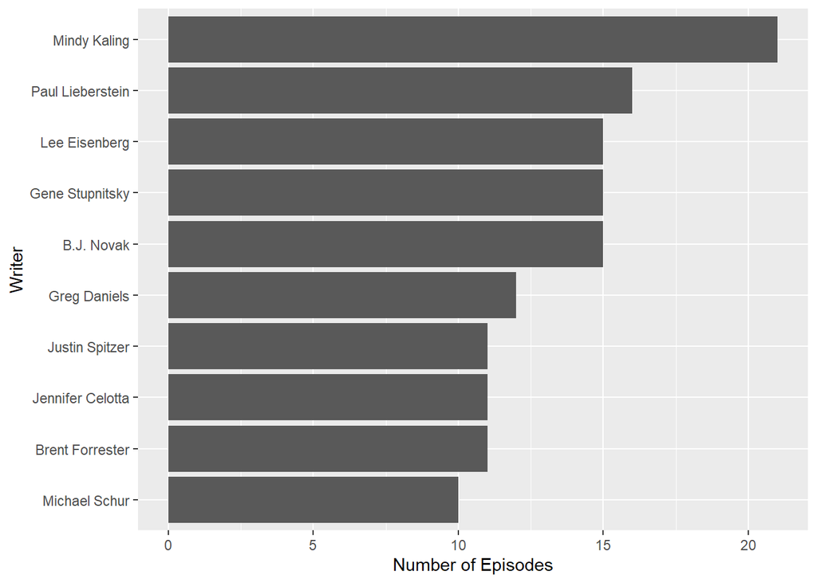

```r
writers <- office |>
  separate_longer_delim(writer,
                        delim = ";") |>
  count(writer) |>
  filter(n >= 10)

writers |>
  ggplot(aes(x = n, y = reorder(writer, n))) +
  geom_bar(stat = "identity") +
  labs(x = "Number of Episodes", y = "Writer")
```

## Part C [10 Points]

Recreate the following plot displaying the number of office episodes originally aired in each month of the year.

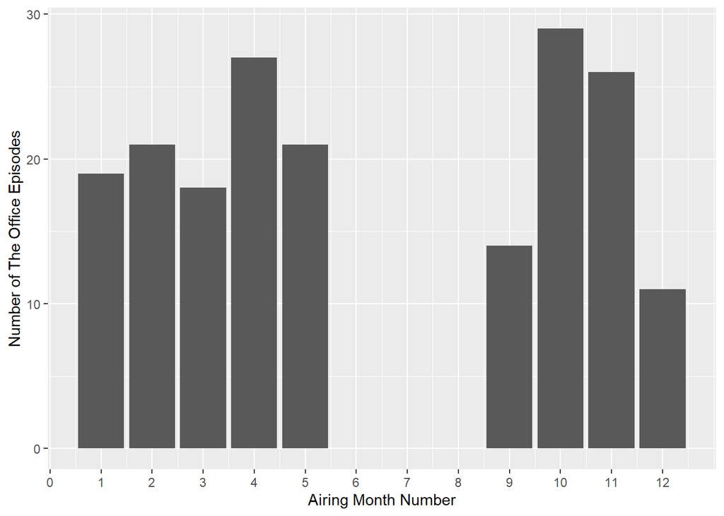

```r
months <- office |>
    mutate(month = parse_number(sub(".*-(.*)-.*", "\\1", air_date))) |>
  count(month)

months |>
  ggplot(aes(x = month, y = n)) +
  geom_bar(stat = "identity") +
  labs(x = "Airing Month Number", y = "Number of The Office Episodes") +
  scale_x_continuous(breaks=0:12)
```

# Problem 2 [35 Points Total]

## Part A [15 Points]

On HuskyCT I have shared a zipped file of 9 jpg images, each depicting a handwritten digit 1-9. Use the readJPEG from the jpeg package to read in each of these images. Assemble them into a single tidy data frame with one row for each pixel in each image.

Each image consists of 28 by 28 pixels, so in total the data frame should have 7056 rows. Columns should be x, y, value (for the pixel value), and digit (dictating which digit image it came from)

```r
digit_one <- readJPEG("C:/Users/kruss/Downloads/digits/digits/img_1.jpg")
digit_two <- readJPEG("C:/Users/kruss/Downloads/digits/digits/img_2.jpg")
digit_three <- readJPEG("C:/Users/kruss/Downloads/digits/digits/img_3.jpg")
digit_four <- readJPEG("C:/Users/kruss/Downloads/digits/digits/img_4.jpg")
digit_five <- readJPEG("C:/Users/kruss/Downloads/digits/digits/img_5.jpg")
digit_six <- readJPEG("C:/Users/kruss/Downloads/digits/digits/img_6.jpg")
digit_seven <- readJPEG("C:/Users/kruss/Downloads/digits/digits/img_7.jpg")
digit_eight <- readJPEG("C:/Users/kruss/Downloads/digits/digits/img_8.jpg")
digit_nine <- readJPEG("C:/Users/kruss/Downloads/digits/digits/img_9.jpg")
```

```r
one_data <- digit_one |>
  raster::as.data.frame()  |>
  pivot_longer(cols = starts_with("V")) |>
  mutate(x = parse_number(name),
         y = rep(28:1, each = 28),
         digit = "1")|>
  dplyr::select(-name)

two_data <- digit_two |>
  raster::as.data.frame()  |>
  pivot_longer(cols = starts_with("V")) |>
  mutate(x = parse_number(name),
         y = rep(28:1, each = 28),
         digit = "2") |>
  dplyr::select(-name)

three_data <- digit_three |>
  raster::as.data.frame()  |>
  pivot_longer(cols = starts_with("V")) |>
  mutate(x = parse_number(name),
         y = rep(28:1, each = 28),
         digit = "3") |>
  dplyr::select(-name)

four_data <- digit_four |>
  raster::as.data.frame()  |>
  pivot_longer(cols = starts_with("V")) |>
  mutate(x = parse_number(name),
         y = rep(28:1, each = 28),
         digit = "4") |>
  dplyr::select(-name)

five_data <- digit_five |>
  raster::as.data.frame()  |>
  pivot_longer(cols = starts_with("V")) |>
  mutate(x = parse_number(name),
         y = rep(28:1, each = 28),
         digit = "5") |>
  dplyr::select(-name)

six_data <- digit_six |>
  raster::as.data.frame()  |>
  pivot_longer(cols = starts_with("V")) |>
  mutate(x = parse_number(name),
         y = rep(28:1, each = 28),
         digit = "6") |>
  dplyr::select(-name)

seven_data <- digit_seven |>
  raster::as.data.frame()  |>
  pivot_longer(cols = starts_with("V")) |>
  mutate(x = parse_number(name),
         y = rep(28:1, each = 28),
         digit = "7") |>
  dplyr::select(-name)

eight_data <- digit_eight |>
  raster::as.data.frame()  |>
  pivot_longer(cols = starts_with("V")) |>
  mutate(x = parse_number(name),
         y = rep(28:1, each = 28),
         digit = "8") |>
  dplyr::select(-name)

nine_data <- digit_nine |>
  raster::as.data.frame()  |>
  pivot_longer(cols = starts_with("V")) |>
  mutate(x = parse_number(name),
         y = rep(28:1, each = 28),
         digit = "9") |>
  dplyr::select(-name)
```

```r
digits <- rbind(one_data, two_data, three_data, four_data, five_data, six_data, seven_data, eight_data, nine_data)
```

## Part B [5 Points]

Use the tidy data frame from part A to recreate the following faceted plot.

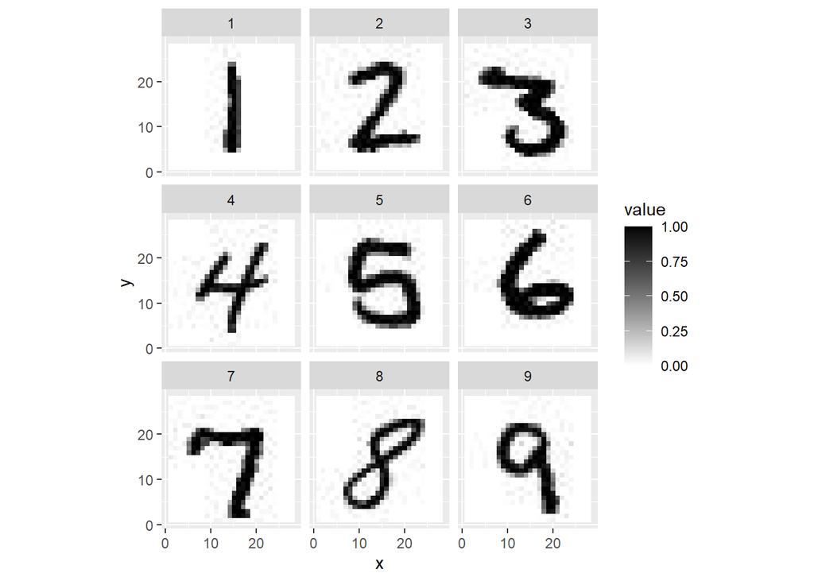

```r
digits |>
  ggplot(aes(x = x,
             y = y,
             fill = value)) +
  geom_raster() +
  scale_fill_gradient(low = "white",
                      high = "black")  +
  coord_fixed() +
  facet_wrap(~ digit)
```

## Part C [5 Points]

List the digits in order of the sum of their pixel intensities (hint: 1 has the lowest, 5 has the highest.)

```r
digits |>
  group_by(digit) |>
  summarise(intensity = sum(value)) |>
  arrange(desc(intensity))
```

```
## # A tibble: 9 × 2
##   digit intensity
##   <chr>     <dbl>
## 1 5         151.
## 2 3         144.
## 3 6         140.
## 4 2         117.
## 5 7         112.
## 6 9         106.
## 7 8         104.
## 8 4          88.5
## 9 1          53.6
```

## Part D [5 Points]

```r
digits_avg <- digits |>
  group_by(x, y) |>
  summarise(value = mean(value))
```

[output not shown]

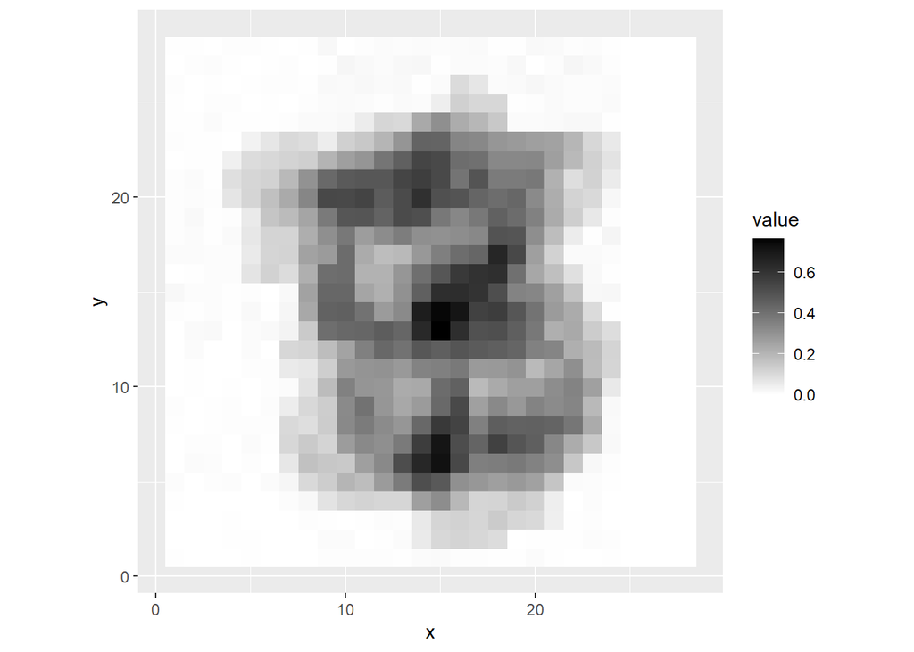

```r
digits_avg |>
  ggplot(aes(x = x,
             y = y,
             fill = value)) +
  geom_raster() +
  scale_fill_gradient(low = "white",
                      high = "black")  +
  coord_fixed()
```

## Part E [5 Points]

```r
digits_avg |>
arrange(desc(value))
```

```
## # A tibble: 784 × 3
## # Groups:   x [28]
##        x     y value
##    <dbl> <int> <dbl>
##  1    15    13 0.765
##  2    15    14 0.749
##  3    15     6 0.725
##  4    15     7 0.715
##  5    16    14 0.714
##  6    14    14 0.684
##  7    18    17 0.650
##  8    14     6 0.646
##  9    14    13 0.639
## 10    16    15 0.624
## # ℹ 774 more rows
```

# Problem 3 [25 Points Total]

The wikipedia webpage on elections in Connecticut, available at https://en.wikipedia.org/wiki/Elections_in_Connecticut, provides a table titled United States presidential election results for Connecticut.

The problem steps are as follows:

- 1. use rvest to scrape this data from web,
- 2. use tidyverse and janitor functions to tidy it,
- 3. use ggplot2 to recreate the following plot.

## Part A [10 Points]

```r
results <- "https://en.wikipedia.org/wiki/Elections_in_Connecticut" |>
  read_html()

election_table <- html_table(results)
results <- election_table[[9]]
results
```

```
## # A tibble: 48 × 7
##    Year  `Republican / Whig` `Republican / Whig` Democratic Democratic
##    <chr> <chr>               <chr>               <chr>      <chr>
##  1 Year  No.                 %                   No.        %
##  2 2020  715,311             39.21%              1,080,831  59.24%
##  3 2016  673,215             40.93%              897,572    54.57%
##  4 2012  634,899             40.72%              905,109    58.06%
##  5 2008  629,428             38.22%              997,773    60.59%
##  6 2004  693,826             43.95%              857,488    54.31%
##  7 2000  561,094             38.44%              816,015    55.91%
##  8 1996  483,109             34.69%              735,740    52.83%
##  9 1992  578,313             35.78%              682,318    42.21%
## 10 1988  750,241             51.98%              676,584    46.87%
## # ℹ 38 more rows
## # ℹ 2 more variables: `Third party` <chr>, `Third party` <chr>
```

## Part B [10 Points]

```r
results <- results[-1,]
results
```

```
## # A tibble: 47 × 7
##    Year  `Republican / Whig` `Republican / Whig` Democratic Democratic
##    <chr> <chr>               <chr>               <chr>      <chr>
##  1 2020  715,311             39.21%              1,080,831  59.24%
##  2 2016  673,215             40.93%              897,572    54.57%
##  3 2012  634,899             40.72%              905,109    58.06%
##  4 2008  629,428             38.22%              997,773    60.59%
##  5 2004  693,826             43.95%              857,488    54.31%
##  6 2000  561,094             38.44%              816,015    55.91%
##  7 1996  483,109             34.69%              735,740    52.83%
##  8 1992  578,313             35.78%              682,318    42.21%
##  9 1988  750,241             51.98%              676,584    46.87%
## 10 1984  890,877             60.73%              569,597    38.83%
## # ℹ 37 more rows
## # ℹ 2 more variables: `Third party` <chr>, `Third party` <chr>
```

```r
results <- results |>
  rename(republican_count = 2,
         republican_share = 3,
         democratic_count = 4,
         democratic_share = 5,
         third_party_count = 6,
         third_party_share = 7) |>
  mutate(share_republican = parse_number(republican_share),
         share_democratic = parse_number(democratic_share),
         share_third_party = parse_number(third_party_share)) |>
  dplyr::select(c(Year, share_republican, share_democratic, share_third_party)) |>
  pivot_longer(cols = starts_with("share")) |>
  mutate(Year = as.numeric(Year)) |>
  mutate(name = ifelse(name == "share_republican", "republican", ifelse(name == "share_democratic", "democratic", "third_party")))
results
```

```
## # A tibble: 141 × 3
##     Year name        value
##    <dbl> <chr>       <dbl>
##  1  2020 republican  39.2
##  2  2020 democratic  59.2
##  3  2020 third_party  1.55
##  4  2016 republican  40.9
##  5  2016 democratic  54.6
##  6  2016 third_party  4.51
##  7  2012 republican  40.7
##  8  2012 democratic  58.1
##  9  2012 third_party  1.22
## 10  2008 republican  38.2
## # ℹ 131 more rows
```